# ISM Tut - Session 2 - Sampling

Niklas Haffert

# Goal of the Session

- Application of different sampling strategies
- Visualization of the effect of different sampling strategies

# Preparations

### Packages

- pacman for package management

```r
suppressWarnings(if (!require("pacman"))
  install.packages("pacman", repos = "http://cran.r-project.org"))
```

- tidyverse: package for all tidy operations (dplyr, ggplot2, …)
- urbnmapr: maps (US States)

```r
pacman::p_load(data.table, devtools, R.utils, tidyverse)
devtools::install_github("UrbanInstitute/urbnmapr")
pacman::p_load(urbnmapr)
```

### Seed

Setting a seed allows to replicate random operations like sampling and get the same results

```r
set.seed(2020)
```

### Data

- “votes” holds the voting behavior of all voters in the US Presidential Election in 2016 source
- “maps_states” is a map of US-States

```r
# loading votes data (created in the "create_us_2016.R" script). If file does not exist it needs to be created via the respective script
votes <-
  fread("../SessionData/usa_2016/us_2016.gz") %>%
  as_tibble()

# storing total turnout in variable
turnout_total <- 136495547

# loading map of US States
map_states <- get_urbn_map("states", sf = TRUE) %>%
  rename(state = state_name)
```

Check out the data

```r
glimpse(votes)
```

```
## Rows: 136,495,547
## Columns: 4
## $ state         <chr> "Alabama", "Alabama", "Alabama", "Alabama", "Alabama", "…
## $ vote          <chr> "Trump", "Trump", "Trump", "Trump", "Trump", "Trump", "T…
## $ voter_id      <int> 1, 2, 3, 4, 5, 6, 7, 8, 9, 10, 11, 12, 13, 14, 15, 16, 1…
## $ turnout_state <int> 2123367, 2123367, 2123367, 2123367, 2123367, 2123367, 21…
```

### Sample Size

Determining the sample size

```r
sample_size <- 1000
```

# Simple Random Sampling

### Sampling

Draw a sample of size 1000 without replacement (SRSWOR)

```r
srs <-
  votes %>%
  # function randomly samples rows from data frame (number of rows determined by size argument)
  sample_n(size = sample_size)
```

### Visualization

Visualize which states are represented in the sample

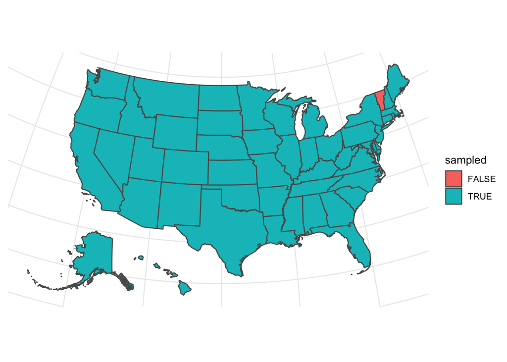

```r
# joining map and our sampled data
map_states %>%
  left_join(srs %>%
              # group sampled data by state as we are interested in state level data
              group_by(state) %>%
              count()) %>%
  # create a labeled variable if an individual was sampled from respective state
  mutate(sampled = ifelse(is.na(n), FALSE, TRUE)) %>%
  # plotting with ggplot
  ggplot() +
  geom_sf(aes(fill = sampled)) +
  theme_minimal() +
  theme(axis.text = element_blank())
```

# Stratified Sampling

### Sampling

All states are included and within each state individuals are sampled (size based on the turnout in the state)

```r
str_sample <-
  votes %>%
  # determine stratum size for each state
  mutate(voters_strata = round(sample_size * turnout_state / turnout_total)) %>%
  group_by(state) %>%
  sample_n(voters_strata) %>%
  ungroup()
```

### Visualization

Visualization of how many individuals were sampled per state

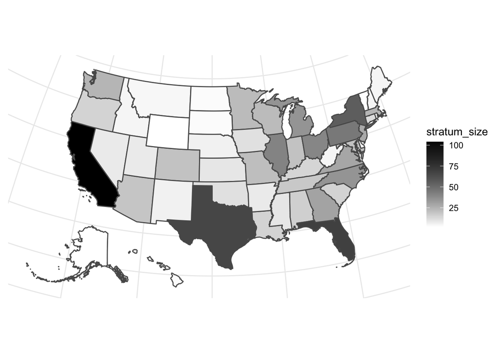

```r
map_states %>%
  left_join(str_sample %>%
              group_by(state) %>%
              count(name = "stratum_size")) %>%
  ggplot(aes(fill = stratum_size)) +
  geom_sf() +
  scale_fill_gradient(low = "white", high = "black") +
  theme_minimal() +
  theme(axis.text = element_blank())
```

# Cluster Sampling / Multi Stage Sampling

### Number of clusters

```r
number_clusters <- 5
```

### Sampling

Two sampling stages: 1. sampling five clusters (states)

```r
states <-
  votes %>%
  # assigning probability for each state being selected (based on turnout)
  mutate(p_1 = turnout_state * number_clusters / nrow(.)) %>%
  group_by(state, p_1) %>%
  summarise() %>%
  ungroup() %>%
  # probability sample of five states
  sample_n(size = number_clusters, weight = p_1) %>%
  # create a vector containing the names of the five states
  pull(state)

states
```

```
## [1] "Georgia"        "New Mexico"     "New York"       "South Carolina"
## [5] "Tennessee"
```

```r
clusters <-
  # filter data set down to five sampled states
  votes %>%
  filter(state %in% states)

## second sampling stage
cl_sample <-
  clusters %>%
  group_by(state) %>%
  # sample individuals from five clusters (number of individuals same for all five states (200))
  sample_n(sample_size / number_clusters) %>%
  ungroup()
```

### Visualization

Visualize which states are represented in the sample

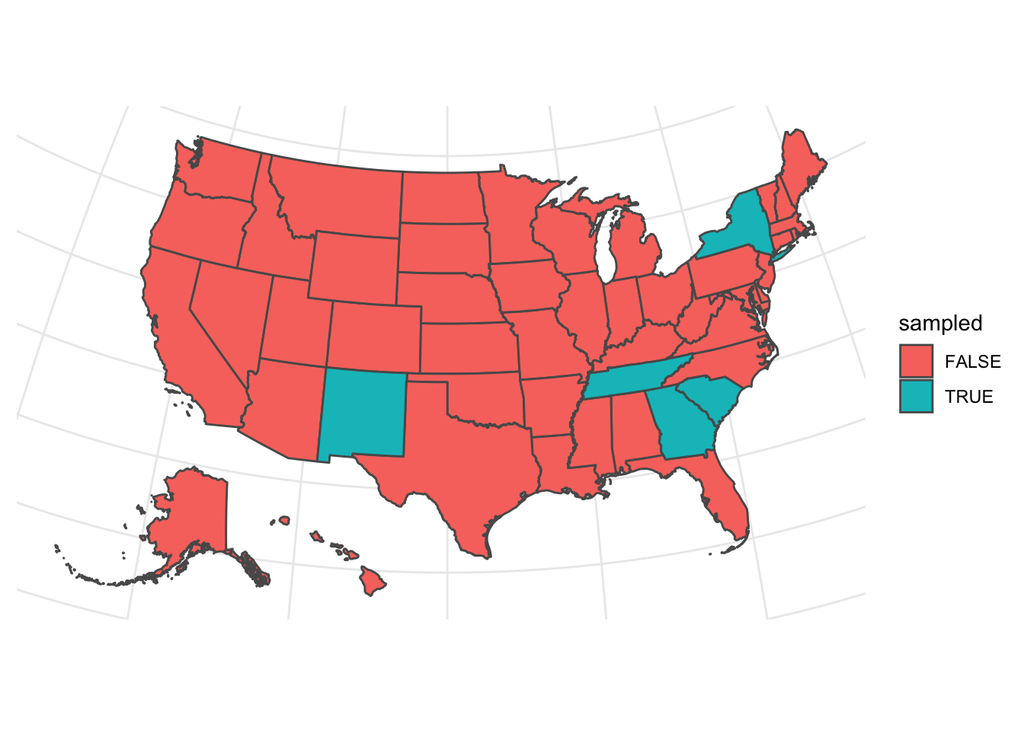

```r
map_states %>%
  left_join(cl_sample %>%
              group_by(state) %>%
              count()) %>%
  mutate(sampled = ifelse(is.na(n), FALSE, TRUE)) %>%
  ggplot() +
  geom_sf(aes(fill = sampled)) +
  theme_minimal() +
  theme(axis.text = element_blank())
```

# Save samples for further usage in the next session

```r
saveRDS(srs, "../SessionData/usa_2016/srs.rds")
saveRDS(str_sample, "../SessionData/usa_2016/str.rds")
saveRDS(cl_sample, "../SessionData/usa_2016/cl.rds")
```